# Lecture 7

### Advanced Statstics and Machine Learning with Python

At this class we will get our hands on the [`sckit-learn`](http://scikit-learn.org/) machine learning library. We will cover the following methods:

- Principal Component Analysis
- Logistic Regression
- Decision Trees (as machine learning technique with training and test sets)

Scikit-learn provides a range of supervised and unsupervised learning algorithms via a consistent interface in Python.

[figure not shown]

```python
import pandas as pd
import numpy as np
import matplotlib.pyplot as plt
import savReaderWriter
import seaborn

%matplotlib inline
```

### Please read the ESS7e02.sav file, from the last class as a dataframe

```python
with savReaderWriter.SavReader('ESS7e02.spss/ESS7e02.sav') as reader:
    header = reader.header
    #print header
    records = reader.all()
ESS=pd.DataFrame(records, columns=header)
```

```python
ESS.head()
```

|  | name | essround | edition | proddate | idno | cntry | tvtot | tvpol | ppltrst | pplfair | ... | inwtm | spltadmf | supqad1 | supqad2 | supqdd | supqmm | supqyr | dweight | pspwght | pweight |
| --- | --- | --- | --- | --- | --- | --- | --- | --- | --- | --- | --- | --- | --- | --- | --- | --- | --- | --- | --- | --- | --- |
| 0 | ESS7e02 | 7.0 | 2.0 | 26.05.2016 | 1.0 | AT | 4.0 | 1.0 | 7.0 | 7.0 | ... | 49.0 | 1.0 | 6.0 | 1.0 | 24.0 | 3.0 | 2015.0 | 0.938075 | 1.027638 | 0.406019 |
| 1 | ESS7e02 | 7.0 | 2.0 | 26.05.2016 | 2.0 | AT | 7.0 | 3.0 | 5.0 | 5.0 | ... | 67.0 | 1.0 | 6.0 | 1.0 | 26.0 | 3.0 | 2015.0 | 0.938075 | 1.017542 | 0.406019 |
| 2 | ESS7e02 | 7.0 | 2.0 | 26.05.2016 | 3.0 | AT | 6.0 | 2.0 | 6.0 | 8.0 | ... | 58.0 | 2.0 | 6.0 | 1.0 | 26.0 | 3.0 | 2015.0 | 0.938075 | 1.631601 | 0.406019 |
| 3 | ESS7e02 | 7.0 | 2.0 | 26.05.2016 | 4.0 | AT | 3.0 | 1.0 | 5.0 | 3.0 | ... | 43.0 | 1.0 | 6.0 | 1.0 | 24.0 | 3.0 | 2015.0 | 0.938075 | 1.333318 | 0.406019 |
| 4 | ESS7e02 | 7.0 | 2.0 | 26.05.2016 | 5.0 | AT | 2.0 | 2.0 | 3.0 | 7.0 | ... | 54.0 | 2.0 | 6.0 | 1.0 | 24.0 | 3.0 | 2015.0 | 0.938075 | 0.638633 | 0.406019 |

5 rows × 601 columns

### Principal Component Analysis

```python
pol_activity_vars=['psppsgv','actrolg','psppipl','cptppol', 'ptcpplt','etapapl']
```

```python
pol_trust_vars=['trstplc','trstep' ,'trstlgl','trstplt', 'trstprt', 'trstun']
```

```python
needed=['psppsgv','actrolg','psppipl','cptppol', 'ptcpplt','etapapl', 'psppsgv','actrolg','psppipl','cptppol', 'ptcpplt','etapapl']
```

```python
data=ESS[needed]
```

```python
data.head()
```

|  | psppsgv | actrolg | psppipl | cptppol | ptcpplt | etapapl | psppsgv | actrolg | psppipl | cptppol | ptcpplt | etapapl |
| --- | --- | --- | --- | --- | --- | --- | --- | --- | --- | --- | --- | --- |
| 0 | 0.0 | 4.0 | 2.0 | 7.0 | 2.0 | 6.0 | 0.0 | 4.0 | 2.0 | 7.0 | 2.0 | 6.0 |
| 1 | 5.0 | 5.0 | 1.0 | 5.0 | 3.0 | 3.0 | 5.0 | 5.0 | 1.0 | 5.0 | 3.0 | 3.0 |
| 2 | 3.0 | 0.0 | 0.0 | 6.0 | 2.0 | 0.0 | 3.0 | 0.0 | 0.0 | 6.0 | 2.0 | 0.0 |
| 3 | 3.0 | 7.0 | 4.0 | 5.0 | 1.0 | 3.0 | 3.0 | 7.0 | 4.0 | 5.0 | 1.0 | 3.0 |
| 4 | 0.0 | 0.0 | 0.0 | 0.0 | 4.0 | 8.0 | 0.0 | 0.0 | 0.0 | 0.0 | 4.0 | 8.0 |

```python
import numpy as np
from sklearn.decomposition import PCA
import pandas as pd
import matplotlib.pyplot as plt
from sklearn.preprocessing import scale
%matplotlib inline
```

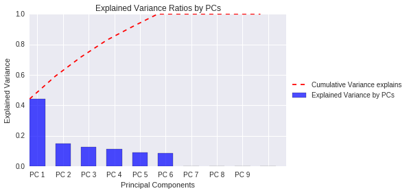

```python
#convert it to numpy arrays
X=data.values

#Scaling the values
X = scale(X)

pca = PCA(n_components=10)

pca.fit(X)

#The amount of variance that each PC explains
var= pca.explained_variance_ratio_

#Cumulative Variance explains
var1=np.cumsum(np.round(pca.explained_variance_ratio_, decimals=4))
plt.plot(var1, linestyle='--',color='r', label='Cumulative Variance explains')
plt.bar(np.arange(len(var)),var, width=0.6, alpha=0.7,
                 color='b',
                 label='Explained Variance by PCs')

plt.xlabel('Principal Components')
plt.ylabel('Explained Variance')
plt.title('Explained Variance Ratios by PCs')
plt.legend(loc='center left', bbox_to_anchor=(1, 0.5))
plt.xticks( np.arange(len(var)) + 0.3, ['PC %d' %i for i in range(1,len(var))])
#plt.xticks(var + bar_width, ('A', 'B', 'C', 'D', 'E')

plt.tight_layout()
plt.show()
```

```python
[(i*100) for i in pca.explained_variance_ratio_]
```

```
[44.151751708626371,
 14.927806942523771,
 12.587341646769584,
 11.035632437681645,
 8.8536539246312014,
 8.4438133397674413,
 1.1489930647364321e-30,
 8.8579272635208113e-31,
 3.7242901128995979e-31,
 1.9175113548491294e-31]
```

So the firs PC explain 44% the secon 15% abt the third 13%. Let's keep only the first one.

```python
pca = PCA(n_components=1)
ESS['PCA1']=pca.fit_transform(X)
```

```python
len(ESS.PCA1)
```

```
40185
```

## Logistic Regression

To run `logistic regressions` these two libaries are the most popualr ones:

- statsmodels similarly to linear regressions
- sckit-learn logistic regression module, which is better for machine learning problems

For a non-learning model, we will use the statsmodels one, becaouse its output is much easier to understand

```python
import statsmodels.api as sm
```

```python
#Let's create our depdendent dummy variable: if the respondent voted at the last elections 1, else 0.
ESS['voted'] = np.where(ESS['vote']==1.0, 1.0, 0.0)
```

```python
ESS.voted.describe()
```

```
count    40185.000000
mean         0.693468
std          0.461059
min          0.000000
25%          0.000000
50%          1.000000
75%          1.000000
max          1.000000
Name: voted, dtype: float64
```

```python
needed=['PCA1','gndr','agea', 'eisced','regunit', 'voted']
```

```python
data2=ESS[needed]
```

```python
data2.head()
```

|  | PCA1 | gndr | agea | eisced | regunit | voted |
| --- | --- | --- | --- | --- | --- | --- |
| 0 | -0.514061 | 1.0 | 51.0 | 3.0 | 2.0 | 1.0 |
| 1 | -0.442968 | 1.0 | 67.0 | 1.0 | 2.0 | 1.0 |
| 2 | -0.938466 | 2.0 | 89.0 | 1.0 | 2.0 | 1.0 |
| 3 | -0.381271 | 1.0 | 32.0 | 3.0 | 2.0 | 1.0 |
| 4 | -1.022879 | 2.0 | 56.0 | 3.0 | 2.0 | 1.0 |

```python
data2.describe()
```

|  | PCA1 | gndr | agea | eisced | regunit | voted |
| --- | --- | --- | --- | --- | --- | --- |
| count | 4.018500e+04 | 40185.000000 | 40185.000000 | 40185.000000 | 40185.000000 | 40185.000000 |
| mean | -3.575838e-16 | 1.534229 | 51.621849 | 4.332786 | 2.384571 | 0.693468 |
| std | 2.301813e+00 | 0.528671 | 50.665639 | 5.870035 | 0.792736 | 0.461059 |
| min | -1.489654e+00 | 1.000000 | 14.000000 | 1.000000 | 1.000000 | 0.000000 |
| 25% | -8.995940e-01 | 1.000000 | 34.000000 | 2.000000 | 2.000000 | 0.000000 |
| 50% | -4.311193e-01 | 2.000000 | 50.000000 | 4.000000 | 2.000000 | 1.000000 |
| 75% | 6.038304e-02 | 2.000000 | 64.000000 | 5.000000 | 3.000000 | 1.000000 |
| max | 2.641415e+01 | 9.000000 | 999.000000 | 99.000000 | 4.000000 | 1.000000 |

#### EXERCISE -Recode Na values (9,999,9999) from the databse into nans.

```python
data2['gndr']=np.where(data2['gndr']==9.0, np.nan, data2['gndr'])
data2['agea']=np.where(data2['agea']==999.0, np.nan, data2['agea'])
data2['eisced']=np.where(data2['eisced']>=8.0, np.nan, data2['eisced'])
```

```python
data2.describe()
```

|  | PCA1 | gndr | agea | eisced | regunit | voted |
| --- | --- | --- | --- | --- | --- | --- |
| count | 4.018500e+04 | 40163.000000 | 40086.000000 | 39919.000000 | 40185.000000 | 40185.000000 |
| mean | -3.575838e-16 | 1.530140 | 49.282118 | 3.889902 | 2.384571 | 0.693468 |
| std | 2.301813e+00 | 0.499097 | 18.740531 | 1.847424 | 0.792736 | 0.461059 |
| min | -1.489654e+00 | 1.000000 | 14.000000 | 1.000000 | 1.000000 | 0.000000 |
| 25% | -8.995940e-01 | NaN | NaN | NaN | 2.000000 | 0.000000 |
| 50% | -4.311193e-01 | NaN | NaN | NaN | 2.000000 | 1.000000 |
| 75% | 6.038304e-02 | NaN | NaN | NaN | 3.000000 | 1.000000 |
| max | 2.641415e+01 | 2.000000 | 114.000000 | 7.000000 | 4.000000 | 1.000000 |

```python
data2.regunit.value_counts()
```

```
2.0    16675
3.0    15639
1.0     5309
4.0     2562
Name: regunit, dtype: int64
```

```python
print pd.crosstab(data2['gndr'], data2['voted'], margins=True, normalize=True)
```

```
voted       0.0       1.0      All
gndr
1.0    0.142469  0.327391  0.46986
2.0    0.163882  0.366258  0.53014
All    0.306352  0.693648  1.00000
```

```python
dummy_eisced = pd.get_dummies(data2['eisced'], prefix='eisced')
print dummy_eisced.head()
```

```
   eisced_1.0  eisced_2.0  eisced_3.0  eisced_4.0  eisced_5.0  eisced_6.0  \
0         0.0         0.0         1.0         0.0         0.0         0.0
1         1.0         0.0         0.0         0.0         0.0         0.0
2         1.0         0.0         0.0         0.0         0.0         0.0
3         0.0         0.0         1.0         0.0         0.0         0.0
4         0.0         0.0         1.0         0.0         0.0         0.0

   eisced_7.0
0         0.0
1         0.0
2         0.0
3         0.0
4         0.0
```

```python
dummy_regunit = pd.get_dummies(data2['regunit'], prefix='regunit')
```

```python
dummies=dummy_regunit.join(dummy_eisced)
```

```python
data2['gender']=np.where(data2['gndr']==1.0, 0.0, 1.0)
```

```python
data2.head()
```

|  | PCA1 | gndr | agea | eisced | regunit | voted | gender |
| --- | --- | --- | --- | --- | --- | --- | --- |
| 0 | -0.514061 | 1.0 | 51.0 | 3.0 | 2.0 | 1.0 | 0.0 |
| 1 | -0.442968 | 1.0 | 67.0 | 1.0 | 2.0 | 1.0 | 0.0 |
| 2 | -0.938466 | 2.0 | 89.0 | 1.0 | 2.0 | 1.0 | 1.0 |
| 3 | -0.381271 | 1.0 | 32.0 | 3.0 | 2.0 | 1.0 | 0.0 |
| 4 | -1.022879 | 2.0 | 56.0 | 3.0 | 2.0 | 1.0 | 1.0 |

```python
cols_to_keep=['PCA1','agea','voted','gender']
```

```python
regr_data=data2[cols_to_keep].join(dummies)
```

```python
regr_data['intercept'] = 1.0
```

```python
dep_variables=[u'PCA1', u'agea', u'gender', u'regunit_1.0', u'regunit_2.0',
       u'regunit_3.0', u'regunit_4.0', u'eisced_1.0', u'eisced_2.0',
       u'eisced_3.0', u'eisced_4.0', u'eisced_5.0', u'eisced_6.0',
       u'eisced_7.0', 'intercept']
```

```python
import statsmodels.api as sm
train_cols = dep_variables
# Index([u'PCA1', u'gndr', u'agea', u'eisced', u'regunit'], dtype='object')

logit = sm.Logit(regr_data['voted'], regr_data[train_cols], missing='drop')

# fit the model
result = logit.fit()
```

```
Optimization terminated successfully.
         Current function value: 0.543782
         Iterations 6
```

```python
print result.summary()
```

```
                           Logit Regression Results
==============================================================================
Dep. Variable:                  voted   No. Observations:                40086
Model:                          Logit   Df Residuals:                    40072
Method:                           MLE   Df Model:                           13
Date:                Thu, 25 Aug 2016   Pseudo R-squ.:                  0.1174
Time:                        09:39:00   Log-Likelihood:                -21798.
converged:                       True   LL-Null:                       -24696.
                                        LLR p-value:                     0.000
===============================================================================
                  coef    std err          z      P>|z|      [95.0% Conf. Int.]
-------------------------------------------------------------------------------
PCA1           -0.0433      0.005     -8.741      0.000        -0.053    -0.034
agea            0.0396      0.001     56.622      0.000         0.038     0.041
gender         -0.1169      0.024     -4.958      0.000        -0.163    -0.071
regunit_1.0    -0.3784   1.23e+06  -3.07e-07      1.000     -2.42e+06  2.42e+06
regunit_2.0    -0.3564   1.23e+06  -2.89e-07      1.000     -2.42e+06  2.42e+06
regunit_3.0    -0.7181   1.23e+06  -5.82e-07      1.000     -2.42e+06  2.42e+06
regunit_4.0     0.3601   1.23e+06   2.92e-07      1.000     -2.42e+06  2.42e+06
eisced_1.0     -0.2024      0.144     -1.405      0.160        -0.485     0.080
eisced_2.0     -0.0915      0.142     -0.645      0.519        -0.369     0.186
eisced_3.0      0.4945      0.142      3.489      0.000         0.217     0.772
eisced_4.0      0.6181      0.142      4.359      0.000         0.340     0.896
eisced_5.0      0.9493      0.143      6.648      0.000         0.669     1.229
eisced_6.0      1.3993      0.145      9.668      0.000         1.116     1.683
eisced_7.0      1.3492      0.145      9.329      0.000         1.066     1.633
intercept      -1.0928   1.23e+06  -8.86e-07      1.000     -2.42e+06  2.42e+06
===============================================================================
```

```python
print result.conf_int()
```

```
                        0             1
PCA1        -5.299023e-02 -3.357857e-02
agea         3.821631e-02  4.095690e-02
gender      -1.631190e-01 -7.068829e-02
regunit_1.0 -2.417108e+06  2.417108e+06
regunit_2.0 -2.417108e+06  2.417108e+06
regunit_3.0 -2.417109e+06  2.417107e+06
regunit_4.0 -2.417108e+06  2.417108e+06
eisced_1.0  -4.847241e-01  7.993690e-02
eisced_2.0  -3.694236e-01  1.864731e-01
eisced_3.0   2.166722e-01  7.722515e-01
eisced_4.0   3.401366e-01  8.959903e-01
eisced_5.0   6.693991e-01  1.229170e+00
eisced_6.0   1.115598e+00  1.682912e+00
eisced_7.0   1.065761e+00  1.632672e+00
intercept   -2.417109e+06  2.417107e+06
```

```python
# odds ratios only
print np.exp(result.params)
```

```
PCA1           0.957639
agea           1.040381
gender         0.889671
regunit_1.0    0.684981
regunit_2.0    0.700173
regunit_3.0    0.487692
regunit_4.0    1.433468
eisced_1.0     0.816773
eisced_2.0     0.912584
eisced_3.0     1.639616
eisced_4.0     1.855332
eisced_5.0     2.583860
eisced_6.0     4.052181
eisced_7.0     3.854405
intercept      0.335287
dtype: float64
```

```python
# odds ratios and 95% CI
params = result.params
conf = result.conf_int()
conf['OR'] = params
conf.columns = ['2.5%', '97.5%', 'OR']
print np.exp(conf)
```

```
                 2.5%     97.5%        OR
PCA1         0.948389  0.966979  0.957639
agea         1.038956  1.041807  1.040381
gender       0.849490  0.931752  0.889671
regunit_1.0  0.000000       inf  0.684981
regunit_2.0  0.000000       inf  0.700173
regunit_3.0  0.000000       inf  0.487692
regunit_4.0  0.000000       inf  1.433468
eisced_1.0   0.615867  1.083219  0.816773
eisced_2.0   0.691133  1.204992  0.912584
eisced_3.0   1.241937  2.164634  1.639616
eisced_4.0   1.405139  2.449761  1.855332
eisced_5.0   1.953063  3.418391  2.583860
eisced_6.0   3.051393  5.381205  4.052181
eisced_7.0   2.903047  5.117531  3.854405
intercept    0.000000       inf  0.335287
```

More sources about Logistic Regression

- [Explanantion with stata outputs](http://www.ats.ucla.edu/stat/stata/library/sg124.pdf)
- [A python example](http://blog.yhat.com/posts/logistic-regression-and-python.html)
- [How to explain logistic regression results to non-statistical audience](http://www.theanalysisfactor.com/explaining-logistic-regression/)

### What is Machine Learning?

"Machine learning is a subfield of computer science that evolved from the study of pattern recognition and computational learning theory in artificial intelligence. In 1959, Arthur Samuel defined machine learning as a "**Field of study that gives computers the ability to learn without being explicitly programmed**".Machine learning explores the study and construction of algorithms that can learn from and make predictions on data. Such algorithms operate by building a model from example inputs in order to make data-driven predictions or decisions, rather than following strictly static program instructions." Source: [Wikipedia](https://en.wikipedia.org/wiki/Machine_learning)

More sources:

- [python-machine-learning-book on github](https://github.com/rasbt/python-machine-learning-book)
- [Learning scikit-learn: Machine Learning in Python](https://www.amazon.com/dp/1783281936?tag=inspiredalgor-20)
- [Statistics, Data Mining, and Machine Learning in Astronomy: A Practical Python Guide for the Analysis of Survey Data](https://www.amazon.com/dp/0691151687?tag=inspiredalgor-20)
- [Recent course on Coursera](https://www.coursera.org/learn/machine-learning)

### Decision Tree

[Decision Trees (DTs)](http://scikit-learn.org/stable/modules/tree.html) are a non-parametric supervised learning method used for classification and regression. The goal is to create a model that predicts the value of a target variable by learning simple decision rules inferred from the data features.

```python
from sklearn.tree import DecisionTreeClassifier, export_graphviz
from sklearn import cross_validation
```

```python
data2.describe()
```

|  | PCA1 | gndr | agea | eisced | regunit | voted | gender |
| --- | --- | --- | --- | --- | --- | --- | --- |
| count | 4.018500e+04 | 40163.000000 | 40086.000000 | 39919.000000 | 40185.000000 | 40185.000000 | 40185.000000 |
| mean | -3.575838e-16 | 1.530140 | 49.282118 | 3.889902 | 2.384571 | 0.693468 | 0.530397 |
| std | 2.301813e+00 | 0.499097 | 18.740531 | 1.847424 | 0.792736 | 0.461059 | 0.499081 |
| min | -1.489654e+00 | 1.000000 | 14.000000 | 1.000000 | 1.000000 | 0.000000 | 0.000000 |
| 25% | -8.995940e-01 | NaN | NaN | NaN | 2.000000 | 0.000000 | 0.000000 |
| 50% | -4.311193e-01 | NaN | NaN | NaN | 2.000000 | 1.000000 | 1.000000 |
| 75% | 6.038304e-02 | NaN | NaN | NaN | 3.000000 | 1.000000 | 1.000000 |
| max | 2.641415e+01 | 2.000000 | 114.000000 | 7.000000 | 4.000000 | 1.000000 | 1.000000 |

```python
TreeData=data2.dropna()
```

```python
TreeData.describe()
```

|  | PCA1 | gndr | agea | eisced | regunit | voted | gender |
| --- | --- | --- | --- | --- | --- | --- | --- |
| count | 39811.000000 | 39811.000000 | 39811.000000 | 39811.000000 | 39811.000000 | 39811.000000 | 39811.000000 |
| mean | -0.007113 | 1.529929 | 49.270327 | 3.890658 | 2.384743 | 0.694707 | 0.529929 |
| std | 2.280054 | 0.499110 | 18.717280 | 1.847006 | 0.790039 | 0.460537 | 0.499110 |
| min | -1.489654 | 1.000000 | 14.000000 | 1.000000 | 1.000000 | 0.000000 | 0.000000 |
| 25% | -0.899028 | 1.000000 | 34.000000 | 2.000000 | 2.000000 | 0.000000 | 0.000000 |
| 50% | -0.430881 | 2.000000 | 49.000000 | 4.000000 | 2.000000 | 1.000000 | 1.000000 |
| 75% | 0.059680 | 2.000000 | 64.000000 | 5.000000 | 3.000000 | 1.000000 | 1.000000 |
| max | 26.414152 | 2.000000 | 114.000000 | 7.000000 | 4.000000 | 1.000000 | 1.000000 |

```python
#dependent
y = TreeData['voted']
#independent
X =TreeData[['gndr', 'agea', 'eisced', 'regunit']]
```

DecisionTreeClassifier is capable of both binary (where the labels are [-1, 1]) classification and multiclass (where the labels are [0, ..., K-1]) classification.

```python
dt = DecisionTreeClassifier(min_samples_split=2)
dt.fit(X, y)
print ('Accuracy:')
print (dt.score(X, y))
```

```
Accuracy:
0.764462083344
```

### [Cross-Validation](http://scikit-learn.org/stable/modules/cross_validation.html)

We did not say how deep the tree can go down, that is why the accuracy is really high and we did no cross-validation. **Learning the parameters of a prediction function and testing it on the same data is a methodological mistake**: a model that would just repeat the labels of the samples that it has just seen would have a perfect score but would fail to predict anything useful on yet-unseen data. This situation is called **overfitting**. To avoid it, it is common practice when *performing a (supervised) machine learning experiment* to hold out part of the available data as a test set X_test, y_test. Note that the word “experiment” is not intended to denote academic use only, because even in commercial settings machine learning usually starts out experimentally.

When evaluating different settings (“hyperparameters”) for estimators, there is still a risk of overfitting on the test set because the parameters can be tweaked until the estimator performs optimally. This way, knowledge about the test set can “leak” into the model and evaluation metrics no longer report on generalization performance. To solve this problem, yet another part of the dataset can be held out as a so-called “validation set”: training proceeds on the training set, after which evaluation is done on the validation set, and when the experiment seems to be successful, final evaluation can be done on the test set.

However, by partitioning the available data into three sets, we drastically reduce the number of samples which can be used for learning the model, and the results can depend on a particular random choice for the pair of (train, validation) sets.

- A model is trained using k-1 of the folds as training data;
- the resulting model is validated on the remaining part of the data (i.e., it is used as a test set to compute a performance measure such as accuracy).

The performance measure reported by `k-fold cross-validation` is then the average of the values computed in the loop. This approach can be computationally expensive, but does not waste too much data (as it is the case when fixing an arbitrary test set), which is a major advantage in problem such as inverse inference where the number of samples is very small.

```python
#Basically we split our dataset into test and train
X_train, X_test, y_train, y_test = cross_validation.train_test_split(X, y, test_size=0.7)
```

```python
X_train.shape, y_train.shape
```

```
((11943, 4), (11943,))
```

```python
X_test.shape, y_test.shape
```

```
((27868, 4), (27868,))
```

```python
#Now we let only 3 depth and fit on the training sets
clf = DecisionTreeClassifier(min_samples_split=2, max_depth=3)
clf.fit(X_train, y_train)
```

```
DecisionTreeClassifier(class_weight=None, criterion='gini', max_depth=3,
            max_features=None, max_leaf_nodes=None, min_samples_leaf=1,
            min_samples_split=2, min_weight_fraction_leaf=0.0,
            presort=False, random_state=None, splitter='best')
```

```python
print ('Accuracy_test:')
print (clf.score(X_test, y_test))
print ('Accuracy_train:')
print (clf.score(X_train, y_train))
```

```
Accuracy_test:
0.741782689823
Accuracy_train:
0.745206397053
```

```python
scores = cross_validation.cross_val_score(clf, X, y, cv=10)
print (scores)
```

```
[ 0.71747865  0.73932697  0.7496233   0.74811652  0.7500628   0.72720422
  0.7535795   0.74497487  0.75150754  0.73643216]
```

```python
print("Accuracy: %0.2f (+/- %0.2f)" % (scores.mean(), scores.std() * 2))
```

```
Accuracy: 0.74 (+/- 0.02)
```

### Visualize the Tree

In order to viualize the tree you need an other program called [Graphiz](http://www.graphviz.org/)

```python
from __future__ import print_function

import os
import subprocess

import pandas as pd
import numpy as np
from sklearn.tree import DecisionTreeClassifier, export_graphviz
```

```python
def visualize_tree(tree, feature_names):
    with open("dt.dot", 'w') as f:
        export_graphviz(tree, out_file=f,
                        feature_names=feature_names)

    command = ["dot", "-Tpng", "dt.dot", "-o", "dt.png"]
    try:
        subprocess.check_call(command)
    except:
        exit
```

```python
feature_names=['gndr', 'agea', 'eisced', 'regunit']
```

```python
visualize_tree(clf, feature_names)
```

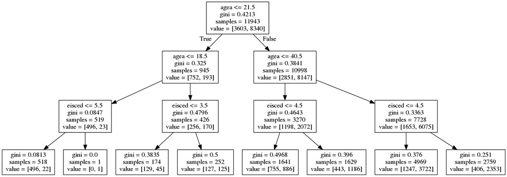

```python
from IPython.display import Image
Image(filename='dt.png')
```

## Homework

- Please, read the [NetworkX Documentation](http://networkx.readthedocs.io/en/networkx-1.11/tutorial/)
- Try to install the [community extension for networkx](http://perso.crans.org/aynaud/communities/) (not trivial, you should do it through the command line using the bitbucket source file)
- Write a half page long description about your final project and send me until tomorrow 3 pm